# Analiza Mikrostruktury Rynków Finansowych i Modelowanie Zmienności Śróddziennej

Klaudia Rajca, Aleksandra Konopelska

2025-12-17

# 1 Metodologia i Plan Analizy

1. **Wstępne przetwarzanie naszych danych:** Ograniczenie zbioru danych do godzin sesji ciągłej (09:00–17:05) oraz eliminacja transakcji pakietowych i błędnych, w celu zapewnienia wiarygodności naszych wyników.
2. **Analiza statystyk opisowych:** Porównanie płynności i charakterystyki obu spółek poprzez analizę średnich cen, wolumenów (kluczowy wskaźnik miary aktywności rynku, oznaczający łączną liczbę akcji, kontraktów lub jednostek finansowych, które zmieniły właściciela w określonym czasie (np. w ciągu dnia), odzwierciedlając zainteresowanie inwestorów danym instrumentem) oraz duracji (odstępów czasu między transakcjami).
3. **Analiza własności stóp zwrotu (dane 1-sekundowe):** Agregacja danych transakcyjnych do częstotliwości 1-sekundowej oraz weryfikacja występowania stylizowanych faktów, takich jak grube ogony rozkładu (kurtoza) czy ujemna autokorelacja.
4. **Badanie sezonowości śróddziennej (dane 5-minutowe):** Analiza rozkładu zmienności i wolumenu w przekroju sesji giełdowej w celu potwierdzenia hipotezy o występowaniu efektu “U-kształtnego”.
5. **Modelowanie i desezonowanie:** Zastosowanie modelu Elastycznej Formy Fouriera (FFF) oraz modelu Engle-Sokalskiej w celu usunięcia deterministycznej składowej sezonowej ze stóp zwrotu.

# 2 Analiza danych transakcyjnych

**Cel naszego projektu** podzielony jest na dwa główne etapy:

1. Własności danych śróddziennych:

Jest to analiza, jak zachowuje się cena akcji w ciągu jednego dnia (od rana do wieczora), zamiast patrzeć na to, jak zmieniła się w ciągu roku.

- **Dane tick-by-tick:**
  - Dane rejestrowane “transakcja po transakcji” (każda pojedyncza sprzedaż jest zapisana).
  - *Co będziemy badały:* Częstotliwość handlu, gwałtowne skoki cen (**kurtoza**) oraz to, czy po spadku cena natychmiast odbija (**autokorelacja**).
- **Dane 5-minutowe:**
  - Dane zagregowane (“zlepione”) w słupki co 5 minut.
  - *Co będziemy badały:* Rozkład aktywności w ciągu dnia, np. czy o godzinie 9:00 rano ruch jest większy niż w porze lunchu (12:00)?
2. Modelowanie zmienności danych śróddziennych:

To wykorzystanie metod matematycznych (modeli FFF i Engle-Sokalskiej) w celu neutralizacji efektu sezonowości.

- **Sezonowość:** Powtarzalny wzorzec zachowania rynku. Na giełdzie przyjmuje on kształt litery **U**: rano jest nerwowo (dużo się dzieje), w południe panuje spokój, a wieczorem znów następuje ożywienie.
- **Zmienność:** Miara tego, jak mocno i gwałtownie zmienia się cena (“szaleje”).

**Nasz głowny cel:** Wziąć wykres zmienności, który naturalnie jest “krzywy” (ma górki rano i wieczorem), i za pomocą modelowania sprawić, żeby stał się **“płaski”**. Jeśli wykres po naszych obliczeniach jest płaski zadanie zostało przez nas wykonane, model zadziałał poprawnie.

## 2.1 Czyszczenie danych (usuwanie transakcji poza sesją)

Wybrane spółki i okres badawczy:

**Okres analizy:** 02.01.2018 – 29.06.2018.

- **Spółka D** – Charakteryzuje się wysokim kursem (~460 PLN) oraz niższą płynnością (rzadsze transakcje).
- **Spółka H** – Charakteryzuje się niskim kursem (~7.50 PLN) oraz bardzo wysoką płynnością.

```r
# wczytanie plików ze spółkami
plik_spolka_D <- "spolkaD.csv"
plik_spolka_H <- "spolkaH.csv"

# nasz zakres dat
start_date <- as.Date("2018-01-02")
end_date   <- as.Date("2018-06-29")

# funkcja która będzie wczytywać dane

# punkt I.1 instrukcji: usuwamy transakcje spoza sesji (przed 9:00 i po 17:05)
wczytaj_dane <- function(sciezka, nazwa_spolki) {

  # 1. wczytanie pliku (polski format CSV: średnik i przecinek)
  df <- read.csv(sciezka, sep = ";", dec = ",") %>%
    rename(
      Data = daty,
      Godzina = godz,
      Kurs = cena,
      Wolumen = vol
    ) %>%
    mutate(
     # naprawaimy godziny: zamieniamy liczbę 90000 na tekst "090000" (dodaje brakujące zero na początku)
      godz_str = sprintf("%06d", as.numeric(Godzina)),
        # tworzymy pełny czas: skleja datę z godziną (czas, nie zwykły napis)
      datetime = ymd_hms(paste(Data, godz_str)),
      # wyciągamy samą date (bez godziny) do późniejszego grupowania
  date = as.Date(datetime),
      # konwersja na liczby (dla pewności)
      Cena = as.numeric(Kurs),
      Wolumen = as.numeric(Wolumen)
    ) %>%

    # 2. filtrowanie okresu badawczego
    filter(date >= start_date & date <= end_date) %>%

    # 3. filtrowanie godzin sesji
    # zostawiamy zakres: 09:00:00 - 17:05:00
    filter(
      (hour(datetime) > 9 | (hour(datetime) == 9 & minute(datetime) >= 0)) &
      (hour(datetime) < 17 | (hour(datetime) == 17 & minute(datetime) <= 5))
    ) %>%
    select(datetime, date, Cena, Wolumen) %>% # wybieramy tylko potrzebne kolumny
    arrange(datetime) %>% # sortujemy od najstarszej do najnowszej (patrząc na czas (datetime))
    mutate(Ticker = nazwa_spolki) # w kolumnie o nazwie 'Ticker' wpisujemy każdemu wierszowi, jak się nazywa ta spółka

  return(df)
}

# używamy naszej funkcji: czyścimy nasze pliki ze społkmai i zapisujemy gotową tabelę w pamięci jako df_D i df_H.df_D
df_D <- wczytaj_dane(plik_spolka_D, "SPOLKA_D")
df_H <- wczytaj_dane(plik_spolka_H, "SPOLKA_H")

# krótkie sprawdzenie poprawności wczytania
podsumowanie_danych <- data.frame(
  Spolka = c("Spółka D", "Spółka H"),
  Liczba_Transakcji = c(nrow(df_D), nrow(df_H)),
  Data_Poczatek = c(min(df_D$date), min(df_H$date)),
  Data_Koniec = c(max(df_D$date), max(df_H$date))
)

kable(podsumowanie_danych, caption = "Podsumowanie naszych wczytanych danych po oczyszczeniu")
```

Podsumowanie naszych wczytanych danych po oczyszczeniu

| Spolka | Liczba_Transakcji | Data_Poczatek | Data_Koniec |
| --- | --- | --- | --- |
| Spółka D | 102568 | 2018-01-03 | 2018-06-29 |
| Spółka H | 197288 | 2018-01-03 | 2018-06-29 |

## 2.2 Statystyki Opisowe

Porównujemy teraz nasze spółki. Musimy sprawdzić: ceny, wolumeny, liczbę transakcji oraz **durację** (czyli jak dużo czasu mija między jedną a drugą transakcją).

```r
# funkcja do policzenia naszych wszystkich wymaganych statystyk
oblicz_statystyki <- function(df) {

  # A. liczymy durację
  # filtrujemy dane: bierzemy tylko te do 16:50
  df_ciagle <- df %>%
    filter(hour(datetime) < 16 | (hour(datetime) == 16 & minute(datetime) <= 50)) %>%
    mutate(duracja = as.numeric(diff(c(datetime[1], datetime)))) # różnica czasu w sekundach

  # B. statystyki dzienne (sumujemy wolumeny i obroty dla każdego dnia osobno)
  stat_dzienne <- df %>%
    group_by(date) %>%
    summarise(
      dzienny_wolumen = sum(Wolumen),
      dzienna_wartosc_obrotu = sum(Cena * Wolumen),
      liczba_transakcji_w_sesji = n()
    )

  # C. zbieramy wszystko w jedną tabelkę podsumowującą
  wyniki <- data.frame(
    Srednia_Cena = mean(df$Cena),
    Mediana_Wolumenu = median(df$Wolumen),
    # średnia duracja (bierzemy tylko dodatnie odstępy > 0)
    Srednia_Duracja_Sek = mean(df_ciagle$duracja[df_ciagle$duracja > 0]),
    Srednia_L_Transakcji_Sesja = mean(stat_dzienne$liczba_transakcji_w_sesji),
    Sredni_Obrot_Dzienny_PLN = mean(stat_dzienne$dzienna_wartosc_obrotu)
  )

  return(wyniki)
}

# używamy funkcji dla obu naszych wybranych spółek
stat_D <- oblicz_statystyki(df_D) %>% mutate(Spolka = "SPOLKA_D")
stat_H <- oblicz_statystyki(df_H) %>% mutate(Spolka = "SPOLKA_H")

# łączymy wyniki i wyświetlamy tabele
tabela_stat <- bind_rows(stat_D, stat_H) %>% select(Spolka, everything())
kable(tabela_stat, digits = 2, caption = "Statystyki opisowe")
```

Statystyki opisowe

| Spolka | Srednia_Cena | Mediana_Wolumenu | Srednia_Duracja_Sek | Srednia_L_Transakcji_Sesja | Sredni_Obrot_Dzienny_PLN |
| --- | --- | --- | --- | --- | --- |
| SPOLKA_D | 462.45 | 13 | 365.46 | 833.89 | 8816312 |
| SPOLKA_H | 7.51 | 1000 | 181.46 | 1603.97 | 27814229 |

Wnioski:

1. **Cena a Wolumen:**
- Spółka D jest droga (ok. 462 zł), więc inwestorzy kupują ją rzadko i w małych ilościach (mediana tylko 13 sztuk).
- Spółka H jest tania (ok. 7.50 zł), więc handluje się nią hurtowo (mediana aż 1000 sztuk).
2. **Czas oczekiwania (Duracja):**
- Na transakcję Spółką D trzeba czekać średnio aż 365 sekund (6 minut). To oznacza niską płynność.
- Na transakcję Spółką H czeka się krócej, bo 181 sekund (3 minuty). To oznacza wyższą płynność.
3. **Liczba transakcji:**
- Spółka H jest znacznie bardziej aktywna –> ma prawie dwa razy więcej transakcji w ciągu dnia (1603) niż Spółka D (833).

**Podsumowanie:** Potwierdziłiśmy założenia. Spółka D to “drogi i powolny” walor, a Spółka H to walor “tani i płynny”.

## 2.3 Agregacja do 1 sekundy

Będziemy musiałY “zbić” (zagregować) nasze dane do częstotliwości 1-sekundowej. Nie bierzemy ostatniej ceny z danej sekundy (Robimy to, aby wynik był wiarygodny: w ciągu jednej sekundy może wystąpić wiele transakcji, a ostatnia z nich może być przypadkowa (np. o bardzo małym wolumenie i nietypowej cenie). Średnia ważona sprawia, że cena dla danej sekundy odzwierciedla to, po ile faktycznie wymieniono większość akcji, eliminując wpływ pojedynczych, przypadkowych transakcji (“szum informacyjny”)). Liczymy średnią ważoną wolumenem (VWAP). Wzór: Suma(Cena * Wolumen) / Suma(Wolumenu).

```r
# funkcja agregująca: zbijamy transakcje w 1-sekundowe punkty
agreguj_do_sekundy <- function(df) {
  df %>%
    mutate(sekunda = floor_date(datetime, "1 second")) %>% # zaokrąglamy czas w dół do pełnej sekundy
    group_by(sekunda) %>%
    summarise(
      # średnia ważona wolumenem
      Cena = sum(Cena * Wolumen) / sum(Wolumen),
      Wolumen = sum(Wolumen)
    ) %>%
    # od razu liczymy stopy zwrotu (potrzebne do punktu 4)
    # wzór: ln(Cena_teraz) - ln(Cena_wczesniej)
    mutate(zwrot_log = c(NA, diff(log(Cena)))) %>%
    filter(!is.na(zwrot_log) & !is.infinite(zwrot_log)) # wyrzucamy puste wiersze (np. pierwszy)
}

# wykonujemy agregację dla obu naszych wybranych spółek
df_D_1s <- agreguj_do_sekundy(df_D)
df_H_1s <- agreguj_do_sekundy(df_H)

# sprawdzamy, wyświetlamy pierwsze 5 wierszy dla Spółki D
kable(head(df_D_1s, 5), caption = "Przykładowe dane po agregacji do 1 sekundy")
```

Przykładowe dane po agregacji do 1 sekundy

| sekunda | Cena | Wolumen | zwrot_log |
| --- | --- | --- | --- |
| 2018-01-03 09:00:01 | 489 | 1 | 0.0000000 |
| 2018-01-03 09:00:46 | 486 | 15 | -0.0061539 |
| 2018-01-03 09:01:17 | 486 | 8 | 0.0000000 |
| 2018-01-03 09:01:33 | 488 | 5 | 0.0041068 |
| 2018-01-03 09:02:00 | 486 | 9 | -0.0041068 |

Wnioski z naszej tabeli, próbki danych (Agregacja):

- Nasz kod działa dobrze: kiedy cena w tabeli spada (z 489 na 486 zł), stopa zwrotu wychodzi ujemna.
- Dowód na małą płynność: W kolumnie z czasem widać przerwy (np. przeskok aż o 45 sekund). Oznacza to, że przez prawie minutę nikt nie handlował (typowe dla mało płynnych spółek, wiele sekund jest “pustych”).
- Potwierdzenie danych: Wysoka cena (~489 zł) i mała liczba akcji (kilka sztuk) potwierdzają, że patrzymy na właściwą, “drogą” wybraną przez nas Spółkę D.

## 2.4 Analiza Stóp Zwrotu

W punkcie 4 musimy sprawdzić, czy nasze stopy zwrotu są “normalne”. Będziemy badały trzy rzeczy:

- **Skośność:** Czy nasz wykres jest przechylony w którąś stronę?
- **Kurtoza (Grube ogony):** Sprawdzamy, czy rozkład stóp zwrotu różni się od normalnego (dla którego kurtoza = 3). Wysoki wynik oznacza występowanie tzw. “grubych ogonów”, czyli na rynku częściej niż w teorii zdarzają się nagłe, ekstremalne skoki cen.

(sprawdzamy czy zdarzają się “szoki cenowe”. Wynik powyżej 3 oznacza, że rynek nie jest stabilny -> często występują nagłe, ekstremalne zmiany ceny (tzw. “grube ogony”)).

- **Autokorelacja:** Sprawdzamy występowanie ujemnej autokorelacji (czy cena “odbija”). Jest to skutek tzw. odbicia bid-ask (bid-ask bounce). Zjawisko to występuje, gdy transakcje zawierane są na zmianę po cenie kupna (bid) i sprzedaży (ask), co powoduje sztuczne wahania ceny (góra-dół).

(Weryfikujemy, czy cena podąża w określonym kierunku (trend), czy chaotycznie “skacze”. Ujemny wynik oznacza, że cena nieustannie oscyluje góra-dół pomiędzy ofertami kupna i sprzedaży. Zamiast płynnego ruchu, obserwujemy “zygzak” wewnątrz spreadu –> cena technicznie się zmienia, mimo że rzeczywista wartość spółki w tym ułamku sekundy pozostaje stała).

```r
# funkcja badająca własności statystyczne
analiza_wlasnosci <- function(df_sek, nazwa) {
  r <- df_sek$zwrot_log # bierzemy nasze stopy zwrotu

  data.frame(
    Spolka = nazwa,
    Skosnosc = skewness(r),       # asymetria
    Kurtoza = kurtosis(r),        # czy są "grube ogony"?
    Autokorelacja_Lag1 = acf(r, plot=FALSE)$acf[2] # czy cena skacze góra-dół? (ujemna korelacja)
  )
}

# zbieramy nasze wyniki do tabeli
wyniki_zwroty <- bind_rows(
  analiza_wlasnosci(df_D_1s, "SPOLKA_D"),
  analiza_wlasnosci(df_H_1s, "SPOLKA_H")
)

kable(wyniki_zwroty, digits = 4, caption = "Własności stóp zwrotu")
```

Własności stóp zwrotu

| Spolka | Skosnosc | Kurtoza | Autokorelacja_Lag1 |
| --- | --- | --- | --- |
| SPOLKA_D | -0.6616 | 77.5433 | -0.1995 |
| SPOLKA_H | -0.2509 | 11.6392 | -0.3208 |

Wnioski z analizy stóp zwrotu:

1. **Ekstremalna Kurtoza (“Grube ogony”):**
- Dla obu spółek kurtoza jest bardzo duża (77.5 dla Spółki D i 11.6 dla Spółki H), znacznie powyżej wartości 3 (charakterystycznej dla rozkładu normalnego). Czyli, rozkład stóp zwrotu nie jest normalny. Na rynku często zdarzają się nagłe, gwałtowne skoki cen.
2. **Ujemna Autokorelacja (Efekt “odbicia”):**
- Obie spółki mają ujemną autokorelację (-0.19 i -0.32). Potwierdza to występowanie zjawiska odbicia bid-ask (bid-ask bounce). Cena w krótkim terminie “skacze” góra-dół pomiędzy ofertami kupna i sprzedaży, zamiast podążać w jednym, płynnym trendzie.

**Podsumowanie:** Nasze otrzymane wyniki (wysoka kurtoza i ujemna autokorelacja) potwierdzają specyficzne własności danych śróddziennych, odróżniające je od danych dziennych.

# 3 Analiza danych 5-minutowych

W tej części projektu bedziemy badały zmienność i płynność wewnątrz dnia. Agregujemy dane do interwałów 5-minutowych, aby sprawdzić, czy na rynku występuje tzw. sezonowość śróddzienną (czy pora dnia ma wpływ na zachowanie inwestorów, gdyż pora dnia ma bardzo duży wpływ. O np: 9:00 ludzie handlują inaczej niż o 13:00).

Zgodnie z instrukcją:

- Transakcje z dogrywki (17:00–17:05) traktujemy jako jeden przedział.
- Usuwamy stopy zwrotu overnight (pierwszą zmianę ceny w dniu, wynikającą z różnicy między zamknięciem wczorajszym a otwarciem dzisiejszym), aby nie zafałszować wyników gigantycznym skokiem na otwarciu.

```r
# Krok 1: agregacja danych do 5 minut

agreguj_5min <- function(df) {
  df %>%
    # zaokrąglamy czas w góre do pełnych 5 minut (np. 09:01 -> 09:05).
    # etykieta mówi, kiedy skończyliśmy zbierać dane do tego konkretnego słupka
    mutate(interval_5min = ceiling_date(datetime, "5 minutes")) %>%
        # wszystko po godzinie 17:00 trafia do jednego worka "17:05"
    mutate(interval_5min = if_else(hour(interval_5min) == 17 & minute(interval_5min) > 0,
                                   ymd_hms(paste(date(interval_5min), "17:05:00")),
                                   interval_5min)) %>%

    group_by(Ticker, date, interval_5min) %>%
    summarise(
      Close = last(Cena),           # cena zamknięcia interwału
      Wolumen = sum(Wolumen),       # suma wolumenu w 5 minut
      Liczba_Trans = n(),           # liczba transakcji w 5 minut
      .groups = "drop"
    ) %>%

    # sortujemy chronologiczne
    arrange(Ticker, date, interval_5min) %>%

    group_by(Ticker, date) %>%
    mutate(
      # stosujemy zwroty logarytmiczne, ponieważ są one addytywne w czasie (można je sumować), co ułatwia analizę statystyczną
      zwrot_log = c(NA, diff(log(Close))),

      # log wolumen, aby zmniejszyć wpływ skrajnie dużych transakcji (outliers) i poprawić czytelność wykresu (rozkład wolumenu jest silnie skośny).
      # dodajemy +1, aby uniknąć błędu log(0) w momentach braku handlu
      log_vol = log(Wolumen + 1)
    ) %>%

    # przed przystąpieniem do dalszej analizy, wyeliminujemy z uzyskanego szeregu czasowego stopy zwrotu overnight
    # dzięki grupowaniu po dacie, pierwszy zwrot w każdym dniu jest NA i go wyrzucamy
    filter(!is.na(zwrot_log)) %>%

    # wyciągamy samą godzinę nam potrzebną (slot czasowy) do wykresów (np. "09:05", "09:10")
    mutate(slot_czasowy = format(interval_5min, "%H:%M"))
}

# przetwarzamy nasze dane dla obu wybranych spółek
dane_5min_D <- agreguj_5min(df_D)
dane_5min_H <- agreguj_5min(df_H)

# tabela (aby łatwiej robić wykresy)
dane_5min_calosc <- bind_rows(dane_5min_D, dane_5min_H)
```

Teraz będziemy obliczały statystyki przekrojowe. Dla każdego przedziału czasowego (np. dla godziny 10:00) liczymy średnią ze wszystkich dni w półroczu. Pozwoli nam to zobaczyć typowy wzorzec dnia giełdowego, eliminując szum z pojedynczych dni.

Będą interesowały nas trzy miary:

- **Średnia liczba transakcji (Aktywność):** Mierzy tłok na rynku (ile razy zawarto transakcję), bez względu na jej wielkość.
- **Średni logarytm wolumenu (Płynność):** Mierzy ilość wymienionego towaru. Logarytm sprawia, że wykres jest bardziej czytelny mimo ogromnych różnic w wolumenie.
- **Średnia wartość bezwzględna zwrotu (Zmienność):** Kluczowa miara. Zamieniamy spadki na plusy (moduł), żeby zmierzyć siłę ruchu ceny, a nie jej kierunek. Ten wskaźnik będzie ujawniał nam “rytm dnia” (sezonowość w kształcie litery U).

```r
# Krok 2: obliczenie średnich przekrojowych

statystyki_przekrojowe <- dane_5min_calosc %>%
  group_by(Ticker, slot_czasowy) %>%
  summarise(
    Srednia_Zwrot = mean(zwrot_log, na.rm = TRUE),

    # miara zmienności (nerwowość rynku), używamy abs() (wartość bezwzględna), żeby zamienić spadki na plusy
    # dzięki temu mierzymy siłę ruchu ceny, a nie kierunek
    # (bez abs() wzrosty i spadki by się zniosły i średnia wyszłaby bliska zeru)
    Srednia_Abs_Zwrot = mean(abs(zwrot_log), na.rm = TRUE),

    Srednia_L_Trans = mean(Liczba_Trans, na.rm = TRUE),
    Sredni_Log_Vol = mean(log_vol, na.rm = TRUE),
    .groups = "drop"
  ) %>%
  # tworzymy sztuczną datę (żeby wykres wiedział, że oś X to czas)
  mutate(czas_wykres = as.POSIXct(paste("2024-01-01", slot_czasowy), format="%Y-%m-%d %H:%M"))
```

Wykresy obrazujące przebieg sesji. Szukamy charakterystycznego kształtu litery “U”, który świadczy o zwiększonej aktywności i nerwowości rynku na otwarciu i zamknięciu sesji, oraz uspokojeniu w środku dnia.

```r
# Krok 3: wykresy

# fun pomocnicza do rysowania
rysuj_sezonowosc <- function(dane, kolumna_y, tytul, y_label) {
  ggplot(dane, aes(x = czas_wykres, y = .data[[kolumna_y]], color = Ticker)) +
    geom_line(size = 1) +
    facet_wrap(~Ticker, scales = "free_y", ncol = 1) + # rozdzielamy spółki na dwa panele jeden po drugim na wykresie, każdy z własną dopasowaną skalą
    scale_x_datetime(date_labels = "%H:%M", date_breaks = "1 hour") +
    labs(title = tytul, x = "Godzina", y = y_label) +
    theme_minimal() +
    theme(legend.position = "none")
}
```

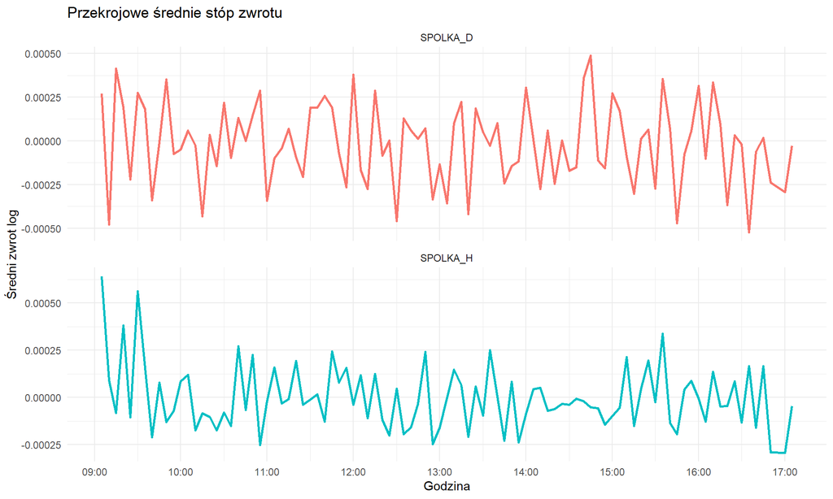

```r
# średnie stopy zwrotu
p0 <- rysuj_sezonowosc(statystyki_przekrojowe, "Srednia_Zwrot",
                       "Przekrojowe średnie stóp zwrotu", "Średni zwrot log")
p0
```

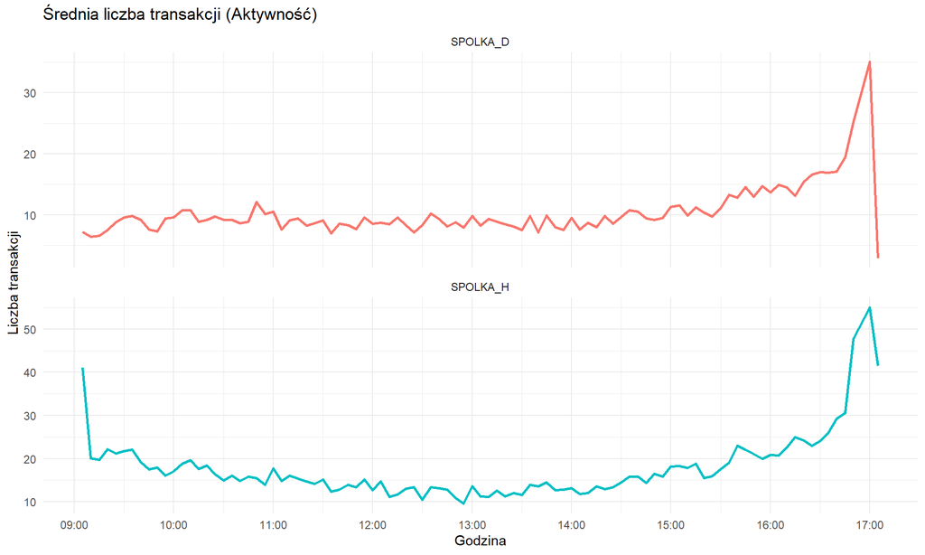

```r
# Średnia liczba transakcji (aktywność)
p1 <- rysuj_sezonowosc(statystyki_przekrojowe, "Srednia_L_Trans",
                       "Średnia liczba transakcji (Aktywność)", "Liczba transakcji")
p1
```

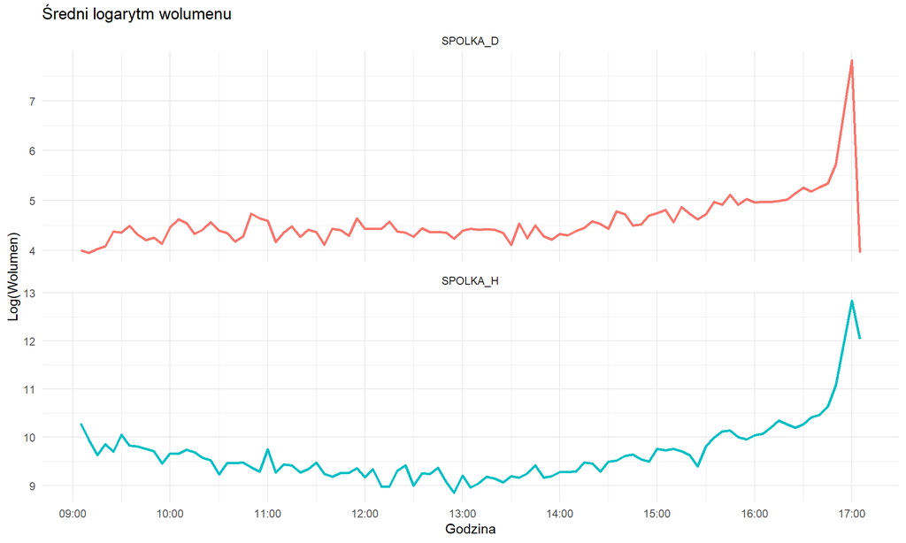

```r
# średni logarytm wolumenu (płynność)
p2 <- rysuj_sezonowosc(statystyki_przekrojowe, "Sredni_Log_Vol",
                       "Średni logarytm wolumenu", "Log(Wolumen)")
p2
```

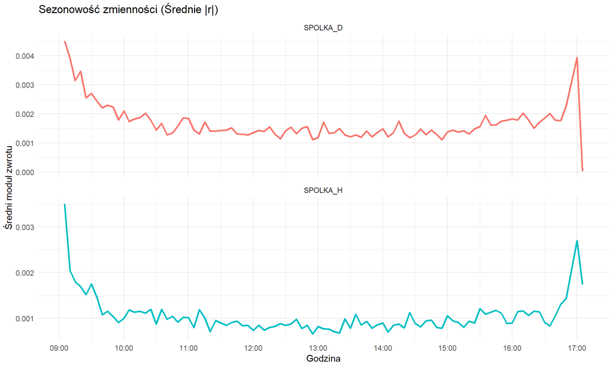

```r
# zmienność (średnie absolutne zwroty) -> ważne dla sezonowości
p3 <- rysuj_sezonowosc(statystyki_przekrojowe, "Srednia_Abs_Zwrot",
                       "Sezonowość zmienności (Średnie |r|)", "Średni moduł zwrotu")
p3
```

## 3.1 Interpretacja wykresów (Porównanie naszych wybranych spółek SPOLKA_D i SPOLKA_H):

**1. Przekrojowe średnie stopy zwrotu (Kierunek zmian cen):** Wykres średnich stóp zwrotu (pierwszy wykres) wyraźnie różni się od pozostałych. Oscyluje on wokół zera (szum) i nie wykazuje żadnego wyraźnego trendu ani kształtu “U”. Jest to zachowanie oczekiwane i zgodne z hipotezą rynku efektywnego. Oznacza to, że pora dnia nie determinuje kierunku zmian cen (zysk czy strata są losowe), a jedynie ich intensywność, co analizujemy w kolejnych punktach.

**2. Aktywność inwestorów (Liczba transakcji i Wolumen):**

**3. Sezonowość Zmienności (Średnie $|r|$):**

- **Dynamika ryzyka:** Wykresy średnich modułów zwrotu potwierdzają obserwacje z wolumenu. SPOLKA_H ma gładki przebieg w kształcie litery “U” –> duża zmienność rano (poszukiwanie ceny równowagi) i wieczorem, a stabilizacja w południe.
- **Nieregularność:** SPOLKA_D wykazuje wysoką zmienność na otwarciu, jednak w ciągu dnia wykres jest mocno “poszarpany” (zaszumiony), co wynika z mniejszej płynności tej spółki.

**Wniosek:** Wykresy jednoznacznie potwierdzają występowanie śróddziennej sezonowości zmienności i aktywności. Parametry te nie są stałe, lecz silnie skorelowane z porą dnia (efekt otwarcia, lunchu i zamknięcia). Natomiast same stopy zwrotu (kierunek) nie wykazują sezonowości.

Obserwacje te uzasadniają konieczność przeprowadzenia procedury odsezonowania danych (w zakresie zmienności) przed estymacją modeli ekonometrycznych, aby usunąć ten deterministyczny wzorzec.

# 4 Modelowanie zmienności danych śróddziennych

W tej części naszego projektu będziemy przekształcały szeregi stóp zwrotu obu spółek w taki sposób, aby pozbawić je wykrytej sezonowości zmienności (kształt litery “U”), aby przygotować dane do dalszego modelowania. Zgodnie z instrukcją będziemy stosowały dwie różne metody dla dwóch spółek.

## 4.1 Metoda Elastycznej Formy Fouriera (FFF) dla SPOLKA_D

Najpierw musimy przygotować dane dzienne (czyli stopy zwrotu obliczone wyłącznie od otwarcia do zamknięcia sesji, bez luki nocnej), aby obliczyć prosty estymator zmienności dziennej (stanowiący punkt odniesienia do oceny, czy ruchy cen wewnątrz dnia są relatywnie duże).

Następnie przygotowujemy zmienne do regresji: sinusy i cosinusy (funkcje odwzorowujące falisty kształt zmienności) oraz zmienne binarne dni tygodnia (pozwalające sprawdzić, czy specyfika handlu np. w piątki różni się od innych dni).

```r
# obliczamy żeby wiedzieć czy zmiany cen w ciągu dnia są duże czy małe

# 1. obliczamy co działo się w skali całego dnia (od rana do wieczora)
dzienne_D <- dane_5min_D %>%
  group_by(date) %>%   # patrzymy na każdy dzień osobno (np. 1 stycznia, 2 stycznia itp)
  summarise(
    # bierzemy cenę z pierwszego słupka (np. 09:05) by mieć jakiś punkt startowy, a (nie mamy ceny idealnie z 09:00:00)
    Open_Day = first(Close),

    # bierzemy cenę z ostatniego słupka (17:05) jako koniec dnia
    Close_Day = last(Close),

    # obliczamy ZYSK/STRATĘ z całej sesji (logarytmicznie)
    # by wiedzieć czy w dany dniu była duża zmiana ceny, czy mała
    Ret_Day = log(Close_Day) - log(Open_Day)
  ) %>%
  ungroup()

# 2. obliczamy "standardową nerwowość" rynku (wariancja), (liczba która mówi nam jak przeciętnie w tym półroczu rynek był nerwowy)
# używamy do tego wariancji z próby
var_daily_sample <- var(dzienne_D$Ret_Day, na.rm = TRUE)

# liczymy ile jest 5 minutowych kawałków w jednym dniu
D_intervals <- length(unique(dane_5min_D$slot_czasowy))

# dalej dzielimy "nerwowość całego dnia" na powyższe kawałki, żeby uzyskać "przeciętną nerwowość na 5 minut"
# to będzie nasza miara; do tej liczby będziemy porównywały co się dzieje o 10:00 czy 12:00
sigma_norm_sq <- var_daily_sample / D_intervals

# 3.szykujemy tabelę którą wrzucimy do modelu (regresji)
dane_fff <- dane_5min_D %>%
  group_by(date) %>%
  # numerujemy słupki w ciągu dnia: 1, 2, 3... aż do 97
  # by model FFF wiedział który to jest moment dnia (czy rano czy wieczór)
  # żeby narysować falę w dobrym miejscu.
  mutate(n = row_number()) %>%
  ungroup() %>%
  mutate(

    # (log) by wykres był ładniejszy dla statystyki
    # dodajemy + 0.00000001 gdy zmiana ceny wyniesie 0 (bo logarytm z zera to błąd).
    y_fff = 2 * log(abs(zwrot_log) + 0.00000001) - 2 * log(sqrt(sigma_norm_sq)),

    # + jaki dzień tygodnia, by sprawdzić, czy np. w piątki ludzie handlują inaczej niż w poniedziałki
    day_of_week = wday(date, label = TRUE)
  )
```

Wybieramy model. Pętla sprawdzi rzędy opóźnień Fouriera oraz wersję z dniami tygodnia (dummies) i bez. Wybierzemy ten, który ma najniższe kryterium informacyjne AIC (kryterium oceny modelu –> im niższa wartość AIC, tym lepszy model, czyli taki, który najdokładniej opisuje dane przy najmniejszym stopniu skomplikowania).

```r
licz_aic_fff <- function(data, P, use_dummies) {

  # baza: zwykła parabola ("U"), n + n^2
  formula_str <- "y_fff ~ n + I(n^2)"

  # + do wzoru "fale" (sinusy i cosinusy).
  # parametr P mówi nam, ile tych fal dodać
  for (p in 1:P) {
    data[[paste0("sin", p)]] <- sin(2 * pi * p * data$n / D_intervals)
    data[[paste0("cos", p)]] <- cos(2 * pi * p * data$n / D_intervals)
    # dopisujemy je do wzoru matematycznego
    formula_str <- paste0(formula_str, " + sin", p, " + cos", p)
  }

  # czy uwzględniamy dni tygodnia?
  # use_dummies = TRUE -> sprawdzimy, czy np. w poniedziałki jest inna zmienność niż w piątki
  if (use_dummies) {
    formula_str <- paste0(formula_str, " + day_of_week")
  }

  # następnie budujemy model (lm) na podstawie tego wzoru który skleiliśmy powyżej
  model <- lm(as.formula(formula_str), data = data)

  return(AIC(model))
}

# tabela ze wszystkimi kombinacjami do sprawdzenia
# sprawdzimy wersję bez dni tygodnia (FALSE) i z dniami tygodnia (TRUE)
# !!! TU ZMIANA: ZWIĘKSZAMY ZAKRES P DO 8 !!!
wyniki_aic <- expand.grid(P = 1:8, Dummies = c(FALSE, TRUE))
wyniki_aic$AIC <- NA # pusta kolumna na wyniki

# petla: sprawdzamy każdą kombinację po kolei
for (i in 1:nrow(wyniki_aic)) {
  wyniki_aic$AIC[i] <- licz_aic_fff(dane_fff, wyniki_aic$P[i], wyniki_aic$Dummies[i])
}

wyniki_aic
```

```
##    P Dummies      AIC
## 1  1   FALSE 69914.11
## 2  2   FALSE 69915.65
## 3  3   FALSE 69918.35
## 4  4   FALSE 69922.05
## 5  5   FALSE 69925.58
## 6  6   FALSE 69927.70
## 7  7   FALSE 69926.87
## 8  8   FALSE 69929.67
## 9  1    TRUE 69899.88
## 10 2    TRUE 69901.49
## 11 3    TRUE 69904.38
## 12 4    TRUE 69908.16
## 13 5    TRUE 69911.75
## 14 6    TRUE 69913.88
## 15 7    TRUE 69913.13
## 16 8    TRUE 69915.92
```

```r
best_model_params <- wyniki_aic[which.min(wyniki_aic$AIC), ]
```

```r
print(paste("Najlepszy model: P =", best_model_params$P, ", Dummies =", best_model_params$Dummies))
```

```
## [1] "Najlepszy model: P = 1 , Dummies = TRUE"
```

W tej części korzystamy z wyników castingu. Skoro już mamy najlepsze parametry dzięki powyższej tabeli, ile fal (P) i czy dni tygodnia są potrzebne, to teraz będziemy budować nasz ostateczny model, wyciągamy z niego kształt “U” i usuwamy go z naszych danych.

```r
# 1. nasze parametry z poprzedniego kroku
best_P <- best_model_params$P
use_dummies <- best_model_params$Dummies

# 2. nowa tabela w której zbudujemy nasz model
dane_fff_final <- dane_fff

# nasz wykres, standardowa parabola (n + n^2) ("U")
formula_final <- "y_fff ~ n + I(n^2)"

# 3. + do tabeli i do przepisu tyle fal (sinusów/cosinusów), ile wygrało w naszym powyższym castingu
for (p in 1:best_P) {
  s_name <- paste0("sin", p) # + nazwy
  c_name <- paste0("cos", p)

  # obliczamy wartości fal i wpisujemy do kolumn w tabeli
  dane_fff_final[[s_name]] <- sin(2 * pi * p * dane_fff_final$n / D_intervals)
  dane_fff_final[[c_name]] <- cos(2 * pi * p * dane_fff_final$n / D_intervals)

  # dopisujemy fale do naszej formuły
  formula_final <- paste0(formula_final, " + ", s_name, " + ", c_name)
}

# 4. jeśli w naszym castingu wyszło, że dni tygodnia są ważne, to też dopisujemy je do przepisu
if (use_dummies) {
  formula_final <- paste0(formula_final, " + day_of_week")
}

# 5. start regresji (lm)
model_fff <- lm(as.formula(formula_final), data = dane_fff_final)

# 6. wyciągamy z modelu to, co nas interesuje -> kształt sezonowości
# model będzie zwracał wynik w logarytmach (bo tak go uczyłyśmy na początku: 2*log...).
# używamy funkcji exp() by odwrócić logarytm i dostać normalną liczbę
# : przez 2 (bo we wzorze było "2 * log")
dane_fff_final$log_s2_hat <- fitted(model_fff)
dane_fff_final$sezonowosc <- exp(dane_fff_final$log_s2_hat / 2)

# 7. normalizacja
# chcemy żeby średnia "sezonowość" wynosiła 1, dzięki temu nie zmieniamy ogólnego poziomu ryzyka w danych, tylko zmieniamy jego rozkład w czasie dnia
norm_factor <- mean(dane_fff_final$sezonowosc)
dane_fff_final$sezonowosc <- dane_fff_final$sezonowosc / norm_factor

# 8. odsezonowanie (czyszczenie danych)
# dzielimy prawdziwy zwrot przez wyliczoną sezonowość
# np: jeśli o 9:00 rano zmienność jest zwykle 2 razy większa (sezonowość = 2), to dzielimy zwrot przez 2
# dzięki temu zostanie nam "czysty" zwrot, pozbawiony efektu pory dnia.
dane_fff_final$zwrot_odsezonowany <- dane_fff_final$zwrot_log / dane_fff_final$sezonowosc
```

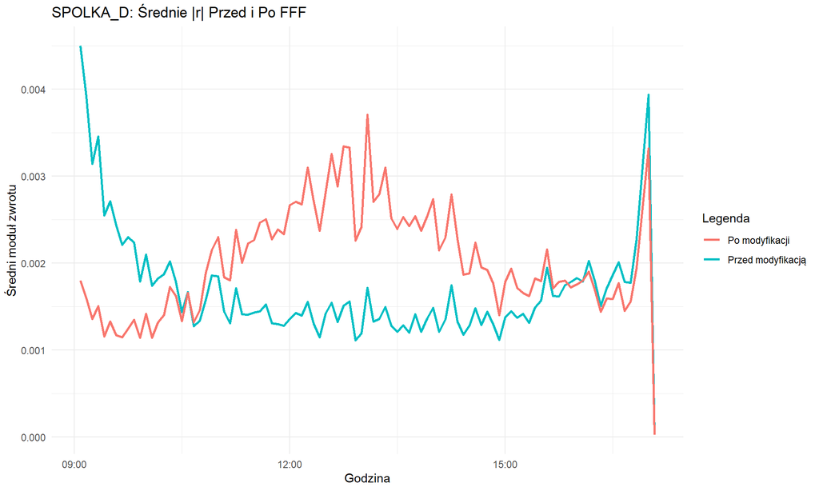

```r
# 1. porównanie przed vs Po (czy usunęliśmy "U")
porownanie_D <- dane_fff_final %>%
  group_by(slot_czasowy) %>%
  summarise(
    # Liczymy średnią "nerwowość" rynku dla każdej godziny (np. średnia dla 10:00, 10:05...)
    # Przed: bierzemy surowe dane (~ "U")
    Przed = mean(abs(zwrot_log), na.rm=TRUE),
    # Po: bierzemy dane wyczyszczone (~ płaska kreska)
    Po = mean(abs(zwrot_odsezonowany), na.rm=TRUE)
  ) %>%
  # + sztuczna data by wykres wiedział że oś X to czas
  mutate(czas = as.POSIXct(paste("2024-01-01", slot_czasowy), format="%Y-%m-%d %H:%M"))

# wykres
ggplot(porownanie_D) +
  geom_line(aes(x = czas, y = Przed, color = "Przed modyfikacją"), size = 1) +
  geom_line(aes(x = czas, y = Po, color = "Po modyfikacji"), size = 1) +
  labs(title = "SPOLKA_D: Średnie |r| Przed i Po FFF", y = "Średni moduł zwrotu", x = "Godzina", color = "Legenda") +
  theme_minimal() +
  scale_x_datetime(date_labels = "%H:%M")
```

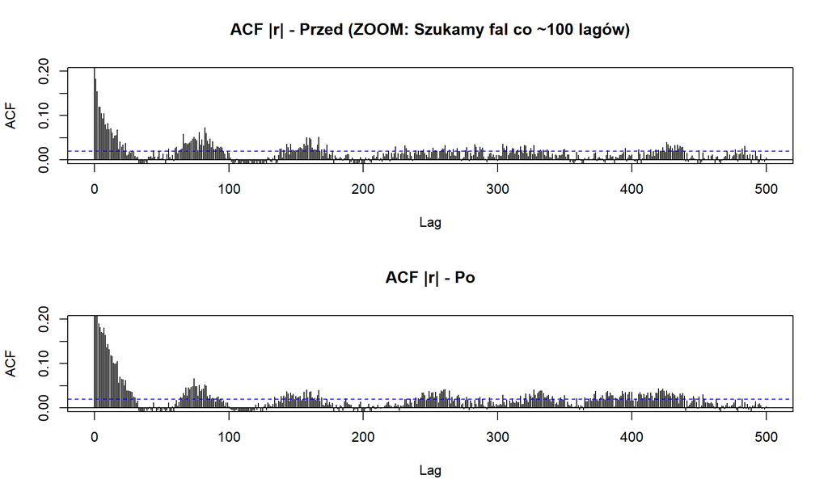

```r
# 2. autokorelacja (ACF)
par(mfrow = c(2, 1)) # by wykresy były jeden pod drugim

# wykres "przed": ~ fale (rynek codziennie powtarza ten sam schemat "U")
acf(abs(dane_fff_final$zwrot_log), lag.max = 500, ylim = c(0, 0.2),
    main = "ACF |r| - Przed (ZOOM: Szukamy fal co ~100 lagów)")

# wykres "po": bez fale zniknąć lub dużo mniejsze (sukces = brak cykliczności)
acf(abs(dane_fff_final$zwrot_odsezonowany), lag.max = 500, ylim = c(0, 0.2),
    main = "ACF |r| - Po")
```

```r
par(mfrow = c(1, 1)) # jeden wykres na ekran
```

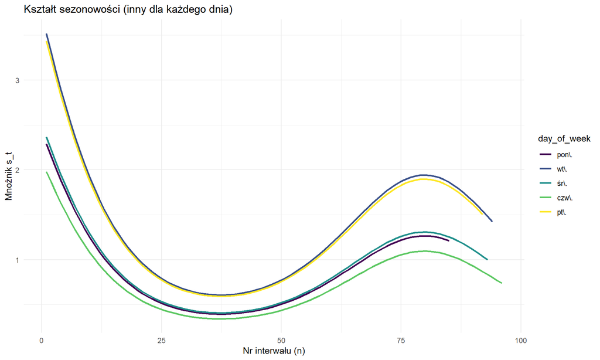

```r
# 3.sezonowość (s_t) -> to co wyciełyśmy z danych
if (use_dummies) {
  # A: jeśli model wykrył różnice między dniami tygodnia, rysujemy osobne linie dla każdego dnia
  ggplot(dane_fff_final, aes(x = n, y = sezonowosc, color = day_of_week)) +
    stat_summary(fun = mean, geom = "line", size = 1) +
    labs(title = "Kształt sezonowości (inny dla każdego dnia)", x = "Nr interwału (n)", y = "Mnożnik s_t") +
    theme_minimal()
} else {
  # B: jeśli dni są takie same, rysujemy jedną linię (jedno "U")
  ggplot(dane_fff_final, aes(x = n, y = sezonowosc)) +
    stat_summary(fun = mean, geom = "line", color = "blue", size = 1) +
    labs(title = "Kształt sezonowości (uniwersalny)", x = "Nr interwału (n)", y = "Mnożnik s_t") +
    theme_minimal()
}
```

Nasz powyższy wykres obrazuje wyizolowany wzorzec sezonowości. Wszystkie krzywe przyjmują kształt litery “U” (wysoka zmienność na otwarciu i zamknięciu, niska w środku dnia). Rozwarstwienie linii potwierdza istotność dni tygodnia (zgodnie z wynikiem kryterium AIC): mimo zachowania wspólnego kształtu sesji, poszczególne dni różnią się ogólnym poziomem zmienności –> widać wyraźny podział na dni o systematycznie wyższej (górne linie) i niższej (dolne linie) aktywności rynku.

## 4.2 Metoda Engle-Sokalskiej dla SPOLKA_H

W tej metodzie musimy oddzielić dwie rzeczy, które mieszają się w cenie akcji:

- Jaki to był dzień (czy na rynku panował ogólny “chaos”, czy spokój?). Obliczymy modelem GARCH.
- Jaka to pora dnia (czy maklerzy są na lunchu, czy dopiero zaczynają pracę?). To nasz wzorzec sezonowy.

Najpierw obliczamy ogólną “nerwowość” całego dnia (GARCH), a potem używamy tego wyniku, żeby oczyścić dane i zobaczyć, jak rynek zachowuje się w konkretnych godzinach (interwałach).

```r
# metoda Engle i Sokalskiej dla naszej spolka_h
# cel: chcemy oczyścić dane z dwóch rzeczy: wpływu konkretnego dnia i wpływu godziny (np. otwarcie giełdy)


# krok 1: przygotowanie danych dziennych
# aby wiedzieć co działo się w skali całego dnia, żeby model GARCH miał na czym pracować będziemy sumować zwroty z 5-minutówek, aby uzyskać jeden zwrot dla całego dnia
dzienne_H <- dane_5min_H %>%
  group_by(date) %>%
  summarise(Ret_Day = sum(zwrot_log, na.rm = TRUE)) %>%
  ungroup()

# krok 2: obliczenie ryzyka dla każdego dnia (model GARCH)
# model garch na danych dziennych
# model wyliczy "sigmę" (liczbę która powie nam jak bardzo ryzykowny/zmienny był każdy konkretny dzień)
spec <- ugarchspec(
  variance.model = list(model = "sGARCH", garchOrder = c(1, 1)),
  mean.model = list(armaOrder = c(1, 1), include.mean = TRUE),
  distribution.model = "norm"
)

fit_garch <- ugarchfit(spec = spec, data = dzienne_H$Ret_Day)

# krok 3: przypisanie ryzyka dnia do każdej 5-minutówki
# bierzemy wyliczoną wyżej sigmę (ryzyko dnia) i doklejamy ją do naszych danych
# (będziemy widziały przy każdej godzinie (np. 10:00), czy ten dzień ogólnie był spokojny czy nerwowy)

# + as.numeric(), żeby pozbyć się formatu xts, by R potraktował wyniki z modelu GARCH jako zwykłe liczby
dzienne_H$sigma_day_garch <- as.numeric(sigma(fit_garch))

dane_es <- dane_5min_H %>%
  left_join(dzienne_H[, c("date", "sigma_day_garch")], by = "date")

# krok 4: wyznaczenie wzorca godziny (sezonowość)
# sprawdzamy, czy dana godzina (slot) jest zazwyczaj bardziej zmienna niż reszta dnia
# dzielimy zmienność chwili przez zmienność dnia i wyciągamy średnią
# s_d będzie mówił nam czy na przykład "o tej godzinie jest zwykle X razy bardziej nerwowo niż średnio"
sezonowosc_ES <- dane_es %>%
  mutate(ratio = zwrot_log^2 / sigma_day_garch^2) %>% # relacja: chwila vs dzień
  group_by(slot_czasowy) %>%
  summarise(s_d_sq = mean(ratio, na.rm=TRUE)) %>%     # uśredniamy wynik dla każdej godziny
  mutate(s_d = sqrt(s_d_sq))                          # pierwiastek daje nam finalny wskaźnik

# dodajemy ten wskaźnik godziny do głównych danych
dane_es <- dane_es %>%
  left_join(sezonowosc_ES[, c("slot_czasowy", "s_d")], by = "slot_czasowy")

# krok 5: ostateczne czyszczenie (odsezonowanie)
# dzielimy nasze zwroty przez oba wykryte efekty:
# 1. przez ryzyko dnia (sigma) -> usuwamy wpływ wydarzeń z danego dnia
# 2. przez wskaźnik godziny (s_d) -> usuwamy wpływ pory dnia (np. otwarcia)
# dostaniemy "czysty zwrot"
dane_es <- dane_es %>%
  mutate(
    zwrot_odsezonowany = zwrot_log / (sigma_day_garch * s_d)
  )
```

Generujemy wykresy porównawcze dla metody Engle i Sokalskiej.

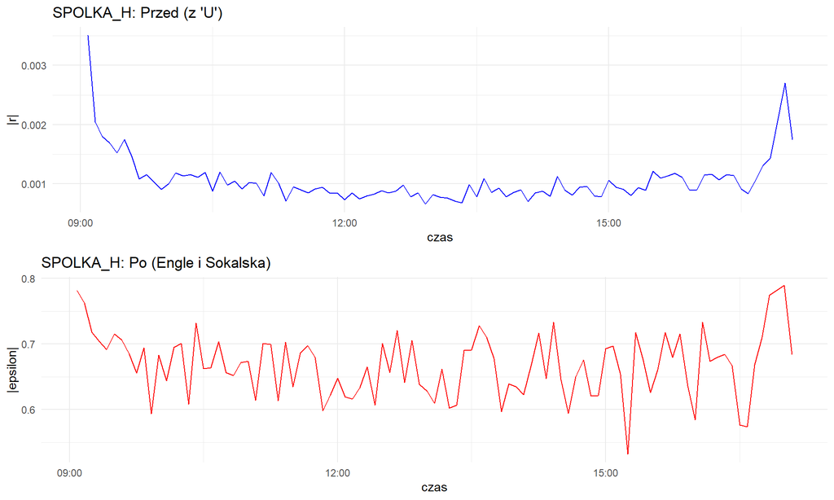

```r
# 1. porównanie średnich |r| (zmienności)

porownanie_H <- dane_es %>%
  group_by(slot_czasowy) %>% # analizujemy każdą godzinę osobno (dla przykładu: wszystkie 9:05 razem)
  summarise(
    # przed: średnia siła zmian ceny w surowych danych; tutaj będziemy spodziewały się "U"
    Przed = mean(abs(zwrot_log), na.rm=TRUE),

    # po: średnia siła zmian w danych oczyszczonych; tutaj spodziewamy się płaskiej linii (szumu)
    Po = mean(abs(zwrot_odsezonowany), na.rm=TRUE)
  ) %>%
  # zamieniamy tekst "09:05" na datę by wykres wiedział, że to oś czasu
  mutate(czas = as.POSIXct(paste("2024-01-01", slot_czasowy), format="%Y-%m-%d %H:%M"))

# p1: wykres "przed" (górny)
p1 <- ggplot(porownanie_H, aes(x = czas, y = Przed)) + geom_line(color = "blue") +
  labs(title = "SPOLKA_H: Przed (z 'U')", y = "|r|") +
  theme_minimal() + scale_x_datetime(date_labels="%H:%M")

# p2: wykres "po" (dolny)
# rysujemy dane oczyszczone; oś y jako |epsilon| (szum/reszta)
p2 <- ggplot(porownanie_H, aes(x = czas, y = Po)) + geom_line(color = "red") +
  labs(title = "SPOLKA_H: Po (Engle i Sokalska)", y = "|epsilon|") +
  theme_minimal() + scale_x_datetime(date_labels="%H:%M")

grid.arrange(p1, p2, ncol = 1)
```

Na górnym wykresie widzimy wyraźne “U” –> wartości są wysokie rano, spadają w południe i rosną na koniec sesji. Dolny wykres pokazuje dane po oczyszczeniu modelem Engle i Sokalskiej. Kształt litery “U” zniknął. Czyli, metoda skutecznie usunęła wpływ pory dnia na zmienność.

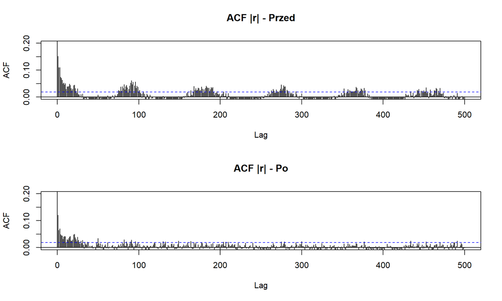

```r
# 2. Autokorelacja (czy usunęliśmy/zmniejszyłyśmy fale)
par(mfrow = c(2, 1)) # Ustawiamy wykresy jeden pod drugim

# wykres przed: widoczne "górki" co ok. 100 lagów (cykliczność co 1 dzień)
acf(abs(dane_es$zwrot_log), lag.max = 500, ylim = c(0, 0.2),
    main = "ACF |r| - Przed")

# wykres po: zmniejszenie/usuniecie "górek" na wykresie = sukces
acf(abs(dane_es$zwrot_odsezonowany), lag.max = 500, ylim = c(0, 0.2),
    main = "ACF |r| - Po")
```

**Przed modyfikacją (górny wykres):** widzimy wyraźne, cykliczne “górki” powtarzające się co ok. 100 opóźnień (jeden dzień sesyjny). Potwierdza to, że zmienność jest silnie zależna od pory dnia.